# Remote Sensing and Spatial Analysis: Replication and Reproducibility via ArcPy and ModelBuilder

Created by M. Brown

09/21/2022

University of California, Merced  
School of Engineering  
Spatial Analysis and Modeling (ENGR 180)

Key assignment steps are in RED

## Case Study Scenario

In many spatial analysis roles, GISers find themselves repeating processes on a regular basis - often for formal/annual reports.  
In Lab 3-1, you learned different concepts in remote sensing and explored two types of spatial analysis that can be done with remotely sensed data: NDVI and NBR. You are working on a multi-year study of how burned area recovers after a fire. You will recreate the process from Lab 3-1 using both ModelBuilder (drag and drop style window and tools) and ArcPy, a python package specifically for working geospatially, which stores python code for each of the geoprocessing tools we commonly use.  
Geoprocessing tools (used in lab 3-1), ModelBuilder, and ArcPy/Python all accomplish the same task, through different approaches.Doing analysis through standalone tools (Geoprocessing) is a great way to undertake initial data exploration, but would have to be redone each time. Using ModelBuilder or ArcPy allows for not only repeating processes on a regular basis, but also for visualizing workflows as well as easily sharing processes with others.

## Introduction

Please read all of the instructions/narrative carefully! You may feel compelled to skim to find which elements you have to satisfy to get full credit. *If you skim, you may miss key sentences and you may end up doing more work than necessary!* Also, if you have questions, give the Case Study handout a second reading. Your question is probably answered here!  
Data Management WARNING: Raster datasets are often large! Depending on how they were encoded, they may also compress well. You will need to extract all .zip files in order for the files to be read by ArcMap, or Excel (or most any other program). Be mindful of the available disk space on personal devices, because some rasters expand to hundreds of megabytes when unzipped. You will need a lot (at least 3GB) of free space for this lab. Have a plan for managing your data in your labs.  
If text is in *italics*, it’s a tool or step within ArcGIS Pro.  
If text is underlined, it’s a file.

### Project Prep

1. Open your Lab 3-1 ArcGIS Pro Project.
2. Confirm you have the following datasets from last week:
- tm_1707_nbr and tm_1710_nbr rasters in your 3-1 geodatabase
- ca_detwiler_20170731_0600_dd83 feature class in your 3-1 geodatabase
3. From Catcourses, download and *Import* the following two layers into your geodatabase:
- National Hydrography Dataset nhd_major_rivers_and_creeks.zip California Natural Resources Agency [2] (Remember to unzip after you download!).  
  Name the output layer CARiversAndCreeks
- Mariposa County Boundaries. Keep the feature class name the same as the shapefile name
4. Look at the *Properties* of the Rivers and Creeks Dataset - see that it says *Geographic Coordinate System: NAD 1983*? Our data is **not** projected. *Project* the Rivers and Creeks dataset to match the projection of MariposaCountyBoundary. Name the output CARiversAndCreeksPRJ. Permanently remove (*Right click - Delete*) the original, unprojected Rivers and Creeks from your geodatabase.

### Part 1a: ModelBuilder Basics

ModelBuilder uses a “drag and drop” approach to building a replicable workflow. Each tool you drag and drop into the workspace is the same as if you were to run a standalone geoprocess.  
The strength of ModelBuilder extends beyond ArcGIS Pro’s classic geoprocessing abilities to emphasize visualization of the workflow. We *see* how a process is going to run.  
Answer: Why might it be beneficial to have a workflow visualization? Who, specifically, may benefit from a workflow visualization?

Per Esri [1] - *“ModelBuilder is a visual programming language for building geoprocessing workflows. Geoprocessing models automate and document your spatial analysis and data management processes. You create and modify geoprocessing models in ModelBuilder, where a model is represented as a diagram that chains together sequences of processes and geoprocessing tools, using the output of one process as the input to another process.*

*ModelBuilder in ArcGIS Pro allows you to do the following:*

*- Build a model by adding and connecting data and tools.*  
*- Iteratively process every feature class, raster, file, or table in a workspace.*  
*- Visualize your workflow sequence as an easy-to-understand diagram.*  
*- Run a model step by step, up to a selected step, or run the entire model.*  
*- Make your model into a geoprocessing tool that can be shared or can be used in Python scripting and other models.”*

Answer: Using complete sentences, describe a scenario in which you, as an engineer, would want to design and replicate a geospatial process on an *annual* basis.

### Part 1b: ArcPy/Python Basics

If you’re new to Python or coding, you’ve got this!  
If you’re a Python pro and would like additional challenges, check out our FREE Esri trainings specific to Python…https://www.esri.com/training/catalog/search/ Search for “python” or “scripting.” You have access to these as long as you have an active UCM Email!  
Per Esri - *“ArcPy is a Python site package that provides a useful and productive way to perform geographic data analysis, data conversion, data management, and map automation with Python.*

*This package provides a rich and native Python experience offering code completion (type a keyword and a dot to get a pop-up list of properties and methods supported by that keyword; select one to insert it) and reference documentation for each function, module, and class.*

*The additional power of using ArcPy is that Python is a general-purpose programming language. It is interpreted and dynamically typed and is suited for interactive work and quick prototyping of one-off programs known as scripts while being powerful enough to write large applications in. ArcGIS applications written with ArcPy benefit from the development of additional modules in numerous niches of Python by GIS professionals and programmers from many different disciplines.*”

Behind every geoprocessing tool we run (Yes, the same ones in the *Geoprocessing* pane and that we used in ModelBuilder) is a snippet of code.  
If you need help with Python syntax (aka code wording and arrangement), the Help page for every tool has a Python section that breaks it all down!

Access this page about *Clip* and scroll to the bottom *Parameters* section. There will be a table with a Python tab with the code AND an example! https://pro.arcgis.com/en/pro-app/2.8/tool-reference/analysis/clip.htm

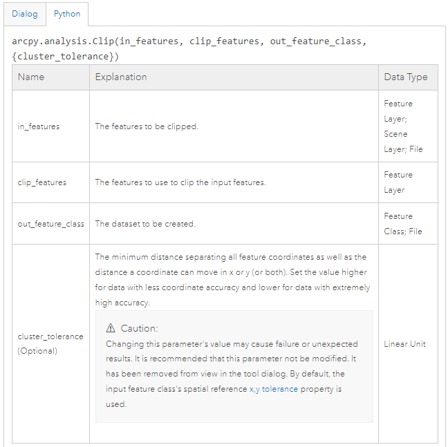

*Python Help for Clip Tool*

Answer: Using complete sentences, describe two benefits of coding using ArcPy/Python.

### Part 2a: ModelBuilder Warm Up

When using ModelBuilder, you work in a separate window, external to our normal map window

1. Click on the Analysis Ribbon, and open ModelBuilder.

[figure not shown]

*Figure 1: ModelBuilder Ribbon*

2. Mentally note the location of the following buttons. These are basic steps you’ll use regularly if working in ModelBuilder.
- Tools
- Group
- AutoFit
- Validate
3. From the *Catalog* Pane, drag and drop CARiversAndCreeksPRJ and MariposaCountyBoundary feature classes into the *Model 1* ModelBuilder window. Click the *Auto Layout* button to tidy the frame.

[figure not shown]

*Figure 2: ModelBuilder with Two Feature Classes Added*

4. Click on the *Tools* button in the *ModelBuilder* Ribbon. This will open our regular *Geoprocessing* pane. Search for *Clip*, then drag and drop it into the ModelBuilder frame to the right of your existing inputs.
5. Connect our inputs to the *Clip* tool (2 approaches). Try both.
- You can click and drag each layer one at a time to connect them to Clip.
- You can double click on *Clip* to open the dialogue box.

For the approach of your choice, set your *Input Features* to CARiversAndCreeksPRJ and your *Clip Feautures* to MariposaCountyBoundary.

6. Name your output MariposaCountyRiversAndCreeks and click *Ok.*
7. Notice how the boxes turned from grey to color? This confirms you have your criteria set (NOTE: It *doesnt* mean they’re correct, just that it is ready to run). To confirm it has the criteria needed to run, click *validate.* When we validate, it is a more robust approach to confirming our model has the required settings applied. It does NOT mean, however, human error didn’t occur. These are just extra ways to minimize (but not wholly eliminate) potential for issues.

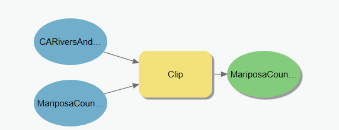

*Figure 3: Prepared Model*

8. Click *Run*. Upon completion, refresh your geodatabase. You should have a MariposaCountyRiversAndCreeks feature class. Drag and drop the feature class into your *Map* Window for visual confirmation. You will use this layer later in a production quality map. If you haven’t saved in a while, save now!

Submit a screenshot of the clipped rivers in your map frame.

Congrats! You have built your first model! This is a very small example, but the same process applies for all models you may build. Bring in inputs, set criteria, run, produces outputs!

9. Click the *Save* icon in the *ModelBuilder* ribbon and save your model as RiverClipMod. Close the *Model 1* window.
10. In *Catalog*, click the dropdown for Toolboxes, then click the dropdown again for the .tbx. See your model is permanently saved?

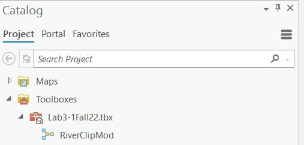

*Figure 4: Your Toolbox*

#### Part 2a-1: Replicability and Updates/Editing

One major benefit of using *ModelBuilder* is that you can save your Model and rerun it at other times, AND even edit it if you need to after it’s been saved. Right click on your RiverClipMod in your *Project Toolbox* and click *Edit.* Edit the output name to YourName_ModEdit. Rerun the Model to generate the renamed output.

Submit a screenshot of your edited model.

### Part 2b: ArcPy Warm Up

In your same ArcGIS Pro project, access the *Analysis* Ribbon. In the top left, click the drop-down next to *Python* and select *Python Window*.

1. Call in (type and hit enter) our arcpy package by typing

   import arcpy
2. Set your Workspace - by doing this, we can streamline coding, as Python knows where data is coming from and going to.  
   We want to set our default geodatabase as our workspace.HINT: Drag and drop your GDB in the *Catalog* pane into the Python window. It will ensure proper syntax. (remember we’re still working in 3-1’s project) Type

   arcpy.env.workspace = *your workspace*

   into the window and hit enter.

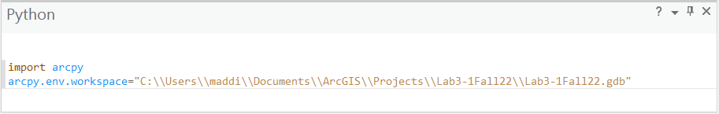

*Setting the Workspace*

Like with the ModelBuilder Warm Up, we are going to use *Clip.*

3. We now want to set our criteria. Type in the following, hitting enter between each line.

in_features = “CARiversAndCreeksPRJ”

clip_features = “MariposaCountyBoundary”

out_feature_class = “MarCoRiversAndCreeks_PY”

You just told it to set your input later to CA Rivers and Creeks, your clip feature (the cookie cutter) to Mariposa County Boundaries, and to name the output MarCoRiversAndCreeksPY.

Now call in the tool by entering…

arcpy.Clip_analysis(in_features, clip_features, out_feature_class)

Congrats! You coded using ArcPy! Drag and drop MarCoRiversAndCreeks_PY from *Catalog* to your Map window to view the resulting layer.

[figure not shown]

*Screenshot of Python Window and GDB!*

In complete sentences, identify whether you preferred clipping the rivers using ModelBuilder or Python (there is no wrong answer). Explain the reasoning behind your preference.

#### Part 2b-1: Sharing

Python code is also shareable! AND you can set computers to run codes at certain times - e.g. Every Friday night at 10pm. If you worked at an agency, this would be done in collaboration with IT.

Enter the following lines of code into the Python window.

import arcpy arcpy.env.workspace = *Your gdb path* string = Hello World.

After entering the code and running it, right click on the code and *Save Transcript*. Save to the desktop for quick/easy access. Name it something relevant to the assignment.

Look for, then open, the Python file you just saved. See how it saved your code? You could email this as an attachment to a coworker.

Submit a screenshot of this python window.

### Part 3: Models with Increased Complexity

Your lab received a multi-million dollar grant from the USGS to understand how burn risk changes on a landscape after a megafire. This is a longitudinal study, meaning it will be repeated over an extended period (the term longitudinal is *not* referring to lat/long).

You successfully completed your first attempt at calculating Zonal Statistics previously, and now you are confident that it is the same process you’ll want to run every three months over the next five years. It sounds repetitive and time-wasting to rerun the process from scratch every few months, so you decide to use ModelBuilder.

As a bonus, your non-GISer boss will appreciate seeing the workflow visually, AND the graphics will look great in your annual reports to the USGS.

#### Part 3b: Build out Processes

[In the spirit of efficiency and focusing on the lesson at hand - you will recycle certain outputs from Lab 3-1, as designated throughout the following steps. Additionally, you will not redo the full lab. Since you are learning about comparability between two new skill sets, the next sections replicate creating NBR and classifying it.]

*NBR Process*  
Your interns (aka you last week) created NBR rasters for July and October.

1. Drag and drop tm_1707_nbr and tm_1710_nbr into a new ModelBuilder window.
2. First you need to recalculate the difference, so drag and drop in *Raster Calculator* from your toolbox into *ModelBuilder*.
3. Click and drag to connect tm_1707_nbr and tm_1710_nbr to *Raster Calculator*, then double click to open the tool.
4. Build your expression in *Raster Calculator*, subtracting tm_1710_nbr from tm_1707_nbr. Save the output as DiffNBR_ModBuild. RUN.
5. *Clip* DiffNBR_ModBuild to the Detwiler fire boundaries, DetwilerBounds. Name the output ClippedDiffNBR
6. RUN  
   This is a good check in point to ensure the processes are running as anticipated. Check your geodatabase - refresh if needed, and confirm that ClippedDiffNBR is present. Drag and drop ClippedDiffNBR to your map frame for a visual check.
7. Drag and drop in the *Reclassify* tool. Set ClippedDiffNBR as the input, and double click on the *Reclassify* tool to open the dialogue window. Set your classifications to match those from Lab 3-1, as shown below.

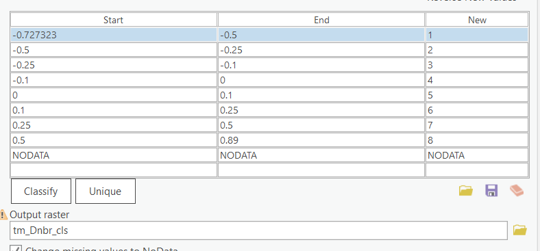

*Table: Classifications*

8. Name your output tm_Dnbr_cls_Modbuild and click *Run*. Then, at the top, click *Run*. The Model should run successfully.
9. Draw a box around these inputs and *Group* them using the corresponding tool in the Ribbon. Name the group Classified NBR.

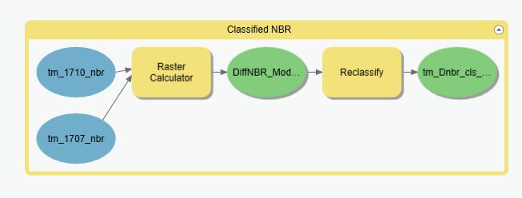

*Image 6: Example Grouped Inputs: NOTE this is NOT the same sequence you are following. Just an example of grouping.*

Submit a screenshot of your Classified NBR Model.

### Part 4: ArcPy with Increased Complexity

Right click on the text anywhere in the Python window and *Clear Transcript*

*NBR Process*  
It is critical to note that *Raster Calculator* is *not* designed for use in ArcPy/Python https://desktop.arcgis.com/en/arcmap/10.3/tools/spatial-analyst-toolbox/raster-calculator.htm

We will use previous outputs we created within the *Raster Calculator* geoprocessing tool to *Classify* our NBR differential data layer we created in ModelBuilder ClippedDiffNBR

Parent Syntax  
https://pro.arcgis.com/en/pro-app/2.8/tool-reference/spatial-analyst/reclassify.htm

Reclassify(in_raster, reclass_field, remap, {missing_values})

Import your arcpy package and set your workspace.

import arcpy

arcpy.env.workspace =“your gdb path”

Enter the following code, one line at a time to set our local variables

reclass_field = VALUE

remap=RemapRange([[-0.727323,-0.500000, 1], [-0.500000, -0.250000, 2],etc…) to match remap table from ModelBuilder)

The final step is to name the function you are using so it will create a correspondingly-named output. (i.e. your output raster will be named reclass_NBR.)

reclass_NBR= arcpy.sa.Reclassify(*your local variables*)

Run the code.

Upon completion, a new layer will be output to your Map window and your geodatabase.

Submit your completed code snippet alongside a screenshot of your output raster from the map window.

### Part 5: Challenge

You have created rasters for the NBR through standalone geoprocessing tools (lab 3-1), ModelBuilder, and Python. Choose ONE of the two following options to respond to. This is designed to help you apply what you learned above in a new scenario.For scoring purposes, this section prioritizes effort (rather than perfection), so do your best!

Challenge A: In ModelBuilder, build a Model for how you would create an NDVI raster (replicating 3-1). Connect your inputs and tools properly.

Challenge B: Find the code you would need to create an NDVI raster (replicating 3-1). Clearly identify each component of the local variables for the code. Remember, we cannot use Raster Calculator for certain steps, so you can call variables we created through ModelBuilder, as we did above.

### References

[1] What is ModelBuilder? Esri. 2022. https://pro.arcgis.com/en/pro-app/2.8/help/analysis/geoprocessing/modelbuilder/what-is-modelbuilder-.htm  
[2] NHD Major Rivers and Creeks. California National Resources Agency. 2022. https://data.cnra.ca.gov/dataset/national-hydrography-dataset-nhd/resource/7d1e7e44-81b1-43fe-95f6-1862eea6ac24